# Conceptual frequency anchors figure and spectrogram image

[Summer G. Eckhardt](https://smith-vidaurrelab.github.io/team/)<sup>1,3</sup>, [Grace Smith-Vidaurre](https://smith-vidaurrelab.github.io/)<sup>1-3*</sup>, [Brittany A. Coppinger](https://brittanycoppinger.weebly.com/)<sup>1,3</sup> <sup>1</sup>Department of Integrative Biology, Michigan State University <sup>2</sup>Department of Computational Mathematics, Science, and Engineering, Michigan State University <sup>3</sup>Ecology, Evolution, and Behavior Program, Michigan State University *Corresponding author (smithvid@msu.edu)

21 August 2025

**Purpose**: This script uses data from the synthetic call metadata to create a conceptual graphic of frequency anchors over time to represent step 3 in the paRsynth pipeline. This graphic is then imported to Inkscape to create part of Figure 1. This code also creates a spectrogram of the resulting synthetic vocalization from the selected character string. This spectrograms is also used in Figure 1.

Load packages and set cores.

```r
# Clean the global environment
rm(list = ls())

# Specify the required packages
X <- c("tidyverse", "tuneR", "seewave", "warbleR")

# Install the packages in X if not already installed
is_installed <- function(p) is.element(p, installed.packages()[,1])

invisible(lapply(1:length(X), function(x){
  if(!is_installed(X[x])){
    install.packages(X[x], repos = "http://lib.stat.cmu.edu/R/CRAN")
  }
}))

cores <- parallel::detectCores() - 4
cores
```

```
## [1] 4
```

```r
# Load all of the packages specified above
invisible(lapply(X, library, character.only = TRUE, verbose = FALSE))
```

Initialize working directories for data on your local machine.

```r
# Initialize a base path (this will need to be different per user)
# path <- "/Users/gracesmith-vidaurre/Desktop" # Grace's path
path <- "/Users/gsvidaurre/Desktop/" # Grace's path
# path <- "C:/Users/britt/Desktop" # Britt's path
# path <- "/Users/summe/OneDrive/Desktop" #Summer's path

# Initialize a path for the local GitHub repo for this manuscript, for saving final figures here
# git_path <- "C:/Users/britt/Documents/GitHub/paRsynth-methods-paper/figures" # Britt's path
git_path <- "/Users/gsvidaurre/Desktop/GitHub_repos/paRsynth-methods-paper/figures"
# git_path <- "/Users/summe/OneDrive/Desktop/github_repo/paRsynth-methods-paper/figures" #Summer's path

# Initialize the directory for analysis on your local computer
analysis_dir <- "paRsynth_methods_synthetic_dataset"

# Combine the base path and the data directory into a single path
analysis_path <- file.path(path, analysis_dir)

# Specify a folder inside the analysis directory where audio will be written out/read in
audio_dir <- "audio"

# Combine the base path, the analysis directory, and the audio directory into a single path
audio_path <- file.path(path, analysis_dir, audio_dir)

# Create the data directory if it doesn't already exist on your computer
if(!dir.exists(analysis_path)){
  dir.create(analysis_path)
}

# Specify a folder inside the github directory where data will be written out/read in
figure_dir <- "Fig_1"

# Combine the base path, the analysis directory, and the data directory into a single path
figure_path <- file.path(git_path, figure_dir)
```

Read in the synthetic call metadata.

```r
synthetic_call_metadata <- read.csv(file.path(analysis_path, "synthetic_call_metadata.csv"))
glimpse(synthetic_call_metadata)
```

```
## Rows: 500
## Columns: 24
## $ Group           <int> 1, 1, 1, 1, 1, 1, 1, 1, 1, 1, 1, 1, 1, 1, 1, 1, 1, 1, …
## $ Individual      <int> 1, 1, 1, 1, 1, 2, 2, 2, 2, 2, 3, 3, 3, 3, 3, 4, 4, 4, …
## $ Call_ID         <int> 1, 2, 3, 4, 5, 1, 2, 3, 4, 5, 1, 2, 3, 4, 5, 1, 2, 3, …
## $ Call            <chr> "CABCAABACCBCCBAA", "CABCAABACCBCCBAA", "CABCAABACBBCC…
## $ Parsons_Code    <chr> "constant-up-down-constant-up-up-down-up-constant-cons…
## $ Frequency1      <int> 4000, 4000, 4000, 4000, 4000, 4000, 4000, 4000, 4000, …
## $ Frequency2      <int> 4000, 4000, 4000, 4000, 4000, 4000, 4000, 4000, 4000, …
## $ Frequency3      <int> 5000, 5000, 5000, 5000, 5000, 5000, 5000, 5000, 5000, …
## $ Frequency4      <int> 4000, 4000, 4000, 4000, 4000, 4000, 4000, 4000, 4000, …
## $ Frequency5      <int> 4000, 4000, 4000, 4000, 4000, 4000, 4000, 4000, 4000, …
## $ Frequency6      <int> 5000, 5000, 5000, 5000, 5000, 5000, 5000, 5000, 5000, …
## $ Frequency7      <int> 6000, 6000, 6000, 6000, 6000, 6000, 6000, 6000, 6000, …
## $ Frequency8      <int> 3000, 3000, 3000, 3000, 3000, 4000, 4000, 4000, 4000, …
## $ Frequency9      <int> 4000, 4000, 4000, 4000, 4000, 4000, 4000, 4000, 4000, …
## $ Frequency10     <int> 4000, 4000, 4000, 3000, 5000, 5000, 4000, 4000, 5000, …
## $ Frequency11     <int> 4000, 4000, 3000, 2000, 4000, 4000, 3000, 5000, 6000, …
## $ Frequency12     <int> 3000, 3000, 3000, 3000, 3000, 3000, 3000, 3000, 3000, …
## $ Frequency13     <int> 3000, 3000, 3000, 3000, 3000, 3000, 3000, 3000, 3000, …
## $ Frequency14     <int> 4000, 4000, 4000, 4000, 4000, 4000, 4000, 4000, 4000, …
## $ Frequency15     <int> 3000, 3000, 3000, 3000, 3000, 3000, 3000, 3000, 3000, …
## $ Frequency16     <int> 4000, 4000, 4000, 4000, 4000, 4000, 4000, 4000, 4000, …
## $ Frequency17     <int> 5000, 5000, 5000, 5000, 5000, 5000, 5000, 5000, 5000, …
## $ audio_file_name <chr> "GroupMembership_Group1_Indiv1_Call1.wav", "GroupMembe…
## $ dataset         <chr> "Group_Membership", "Group_Membership", "Group_Members…
```

# Step 1: Choose a single call for the conceptual representation of the pipeline step. For this call, store the frequency anchor data

```r
# Choose the first call in this dataset (Group 1, Individual 1, Call 1)
filt_data <- synthetic_call_metadata %>%
  slice(1)

glimpse(filt_data)
```

```
## Rows: 1
## Columns: 24
## $ Group           <int> 1
## $ Individual      <int> 1
## $ Call_ID         <int> 1
## $ Call            <chr> "CABCAABACCBCCBAA"
## $ Parsons_Code    <chr> "constant-up-down-constant-up-up-down-up-constant-cons…
## $ Frequency1      <int> 4000
## $ Frequency2      <int> 4000
## $ Frequency3      <int> 5000
## $ Frequency4      <int> 4000
## $ Frequency5      <int> 4000
## $ Frequency6      <int> 5000
## $ Frequency7      <int> 6000
## $ Frequency8      <int> 3000
## $ Frequency9      <int> 4000
## $ Frequency10     <int> 4000
## $ Frequency11     <int> 4000
## $ Frequency12     <int> 3000
## $ Frequency13     <int> 3000
## $ Frequency14     <int> 4000
## $ Frequency15     <int> 3000
## $ Frequency16     <int> 4000
## $ Frequency17     <int> 5000
## $ audio_file_name <chr> "GroupMembership_Group1_Indiv1_Call1.wav"
## $ dataset         <chr> "Group_Membership"
```

```r
# Call string
filt_data$Call
```

```
## [1] "CABCAABACCBCCBAA"
```

```r
# [1] "CABCAABACCBCCBAA"

# Frequency anchors are in columns, pull these out as a vector
freq_cols <- filt_data %>%
  # Select only the columns that start with the pattern "Frequency"
  select(names(.)[grep("^Frequency", names(.))])

glimpse(freq_cols)
```

```
## Rows: 1
## Columns: 17
## $ Frequency1  <int> 4000
## $ Frequency2  <int> 4000
## $ Frequency3  <int> 5000
## $ Frequency4  <int> 4000
## $ Frequency5  <int> 4000
## $ Frequency6  <int> 5000
## $ Frequency7  <int> 6000
## $ Frequency8  <int> 3000
## $ Frequency9  <int> 4000
## $ Frequency10 <int> 4000
## $ Frequency11 <int> 4000
## $ Frequency12 <int> 3000
## $ Frequency13 <int> 3000
## $ Frequency14 <int> 4000
## $ Frequency15 <int> 3000
## $ Frequency16 <int> 4000
## $ Frequency17 <int> 5000
```

```r
# We need to transpose this data frame so that all of the frequency values are in rows not columns, and then we need to convert the resulting matrix to a vector
frequency_anchors <- as.vector(t(freq_cols))

# Looks good
frequency_anchors
```

```
##  [1] 4000 4000 5000 4000 4000 5000 6000 3000 4000 4000 4000 3000 3000 4000 3000
## [16] 4000 5000
```

```r
length(frequency_anchors)
```

```
## [1] 17
```

# Step 2: Make the conceptual graphic

The graphic should show how the frequency values produced from the paRsynth pipeline serve as frequency modulation “anchors” for soundgen to generate synthetic audio files. This should be a line graph of the frequency anchors identified in the previous step.

```r
# Create a data frame of the frequency anchors plus timestamps
freq_anchors <- data.frame(
  freq_anchors = frequency_anchors,
  # The timestamps should be evenly spaced across the duration of the call, which is the soundgen default
  # We generated calls in the first script that had 200 ms duration
  time = round(seq(0.1, 0.3, 0.2/(length(frequency_anchors) - 1)), 3)
)

# X-axis is time, y-axis is frequency
glimpse(freq_anchors)
```

```
## Rows: 17
## Columns: 2
## $ freq_anchors <int> 4000, 4000, 5000, 4000, 4000, 5000, 6000, 3000, 4000, 400…
## $ time         <dbl> 0.100, 0.112, 0.125, 0.138, 0.150, 0.162, 0.175, 0.188, 0…
```

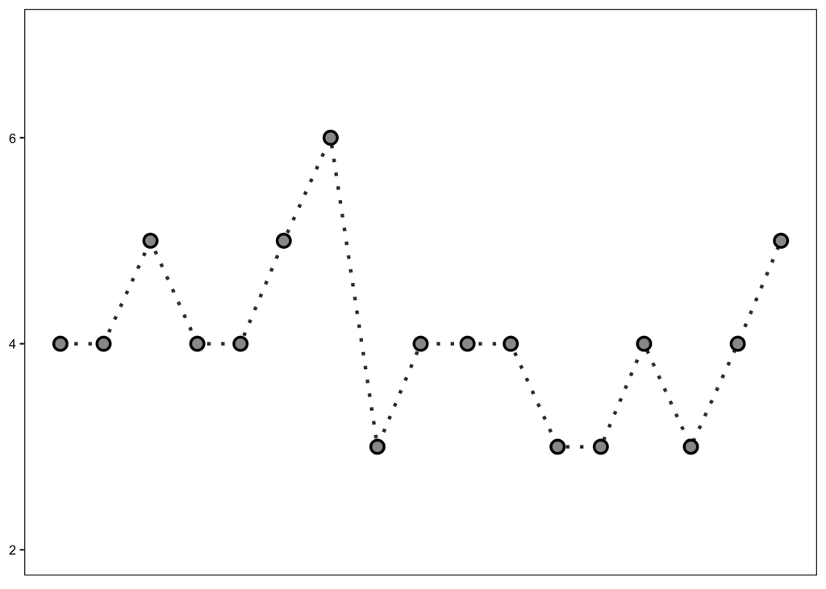

```r
# Make a graphic of the frequency anchors plus a line through them
ggplot(freq_anchors, aes(x = time, y = freq_anchors/1000)) +
  # geom_line(color = scales::alpha("#A8CDECFF"), linetype = "dotted", linewidth = 2) +
  geom_line(color = "grey24", linetype = "dotted", linewidth = 1) +
  geom_point(size = 3, shape = 21, color = "black", fill = "grey60", stroke = 1.2) +
  #geom_point(size = 3, shape = 19, color = "grey56") +
  xlab("Time (s)") +
  ylab("Frequency (kHz)") +
  scale_y_continuous(limits = c(2, 7), breaks = seq(2, 7, 2)) +
  theme_bw() +
  theme(
    panel.grid.minor = element_blank(),
    panel.grid.major = element_blank(),
    panel.border = element_rect(linetype = "solid", fill = NA, color = "black"),
    # axis.title = element_text(size = 16),
    axis.text = element_text(size = 8, color = "black"),
    axis.title.x = element_blank(),
    axis.title.y = element_blank(),
    # Removing numbers and ticks from x axis for figure
    axis.text.x = element_blank(),
    axis.ticks.x = element_blank()
  )
```

Save plot

```r
# This is the size of the graphic for use in Figure 1 creation, done manually in Inkscape
ggsave(file.path(figure_path, "Concept_FreqAnch.tiff"), units = "in", width = 5.025, height = 2.18, dpi = 600)
```

# Step 3: Make a spectrogram of the audio file that corresponds with the call used for this figure

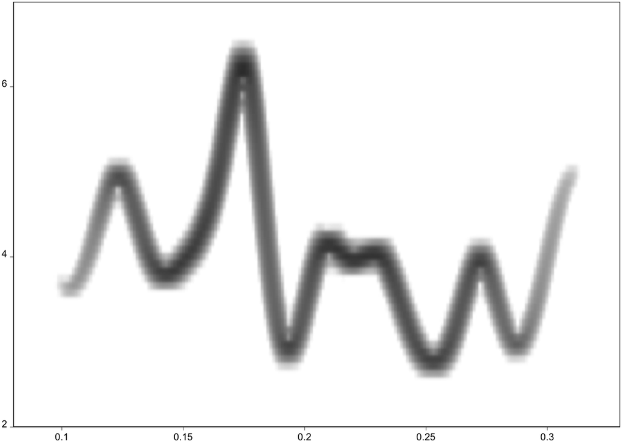

```r
# Set color palette for spectrograms
gray_colors <- reverse.gray.colors.2(12)

# Read in the audio file, return a wave object
tmp_wav <- tuneR::readWave(file.path(audio_path, "GroupMembership_Group1_Indiv1_Call1.wav"))
# str(tmp_wav)

# Use ggspectro to generate a spectrogram
ggspectro(wave = tmp_wav, f = tmp_wav@samp.rate, ovlp = 90) +

  # Plot amplitude values or cells in the spectrogram. Interpolation needs to be TRUE and sit outside of the aes() call to smoothen the otherwise very pixelated appearance of the raster
  geom_raster(aes(fill = amplitude), hjust = 0, vjust = 0, interpolate = TRUE) +

  # Control the x-axis aesthetics
  scale_x_continuous(limits = c(0.08, 0.33), breaks = seq(0.1, 0.3, 0.05), labels = seq(0.1, 0.3, 0.05), expand = c(0, 0)) +

  # Control the y-axis aesthetics
  scale_y_continuous(limits = c(2, 7), breaks = seq(2, 7, 2), labels = seq(2, 7, 2), expand = c(0, 0)) +

  # We want spectrograms to be in grayscale
  # Change the values of limits to change how colors are assigned across amplitude bins
  scale_fill_gradientn(colours = gray_colors, name = "Amplitude \n (dB)", na.value = "transparent", limits = c(-35, 10)) +
  # Use the theme function above to modify the overall plot aesthetics
  theme(
    # Use element_blank() to remove grid lines
    panel.grid.major.y = element_blank(),
    panel.grid.major.x = element_blank(),
    panel.grid.minor = element_blank(),
    panel.background = element_rect(fill = "transparent"),
    panel.border = element_rect(linetype = "solid", fill = NA, color = "black"),
    axis.line = element_line(linewidth = 0.15),
    legend.position = "none",
    plot.background = element_rect(fill = "white"),
    # Control the white space around the figure in the resulting image file
    plot.margin = unit(c(0.1, 0.1, 0.1, 0.1), "lines"), # top, right, bottom, left
    # Turn off the axis titles, which should remove titles for all 3 axes, including amplitude and the amplitude scale bar
    axis.title = element_blank(),
    # Control the size of the x and y-axis text
    axis.text = element_text(size = 8, color = "black", vjust = 0),
    # Control the size of the axis tick lines
    axis.ticks = element_line(color = "black", linewidth = 0.15)
  )
```

Save plot

```r
# Save spectrogram for at appropriate size for use in Inkscape for creating Figure 1
ggsave(filename = file.path(figure_path, "GroupMembership_Group1_Indiv1_Call1.tiff"), units = "in", width = 4.9, height = 2.2, dpi = 600)
```